# Renewable Energy Data Check

Xiaodi Li, Jiamin Zhang, Xinping Yu, Ali Mara

## Forecasting Variable

- Renewable Energy Consumption

We choose renewable energy consumption as our forecasting variable. We are interested to see and try to predict renewable energy consumption in the United States in the years to come. One of the main reasons for that is that, the climate change today remains one of the most crucial issues for lawmakers and government agencies and scientist all over the world. Keeping in mind that there is a positive correlation between lung diseases in general and air pollution and renewable energy is a safe alternative for the climate issues and air pollution we thought it as an important variable to forecast. The measuring units are in quadrillion BTU (British thermal units), and the data is monthly from 1990 to 2015.

## List of indepdent Variables

- Industrial Production

Industrial production index was our other independent variable. The industrial production index data came for FRED, and as an index there is no measuring units. Our reason for choosing the INDPRO was to see if with the industrial development that USA has had in the last decades, we are moving more towards consuming renewable energy, keeping in mind that more industrial production means we need more resources of production and at the same time it means more technological advancement.

- Temperature Change in United States

One of the independent variables we wanted to use was average monthly temperature in USA. The units are Celsius. As we all know according most scientists there is valuable data that there is a big increase in temperature during the last decade because of the climate change. We wanted to see if this negative phenomenon has had at least a positive impact such as that we are consuming more renewable energy trying to preserve the planet.

- Average Retail Price of Electricity

Another independent variable we choose is the average retail price of electricity, we wanted to see if the prices of energy affect renewable energy consumption in any order, if when we have high prices, we turn to renewable energy as an alternative, and more renewable energy means more low prices. The units for this variable are cents/kilowatt-hour or as commonly written cents/kWh.

- Co2 Emission

We wanted to see carbon dioxide emissions as an independent variable to see that effect that the volume of CO2 emissions has in the renewable energy consumption. We wanted to see a trend where less CO2 means we are consuming more renewable energy which logically should hold true. The data units are volume units and they are million metric tons of carbon dioxide. ## Time Series Plot of the Renewable Energy Consumption

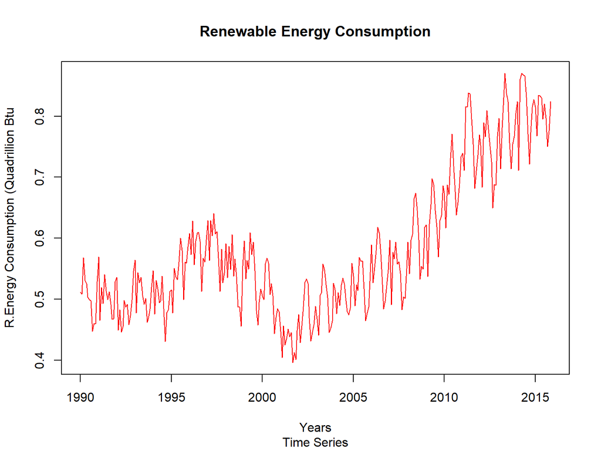

We can see from the time series plot of renewable energy consumption that our data , has an a seasonal , and we also can see that the data is not stationary since it doesn’t center around a constant mean. ## White Noise Test

```
##
##  Box-Ljung test
##
## data:  data.ts[, 1]
## X-squared = 4447.8, df = 24, p-value < 2.2e-16
```

```
## [1] 1560
```

```
## [1] 75
```

```
## [1] 1475
```

## Correlation plots and correlation coefficient.

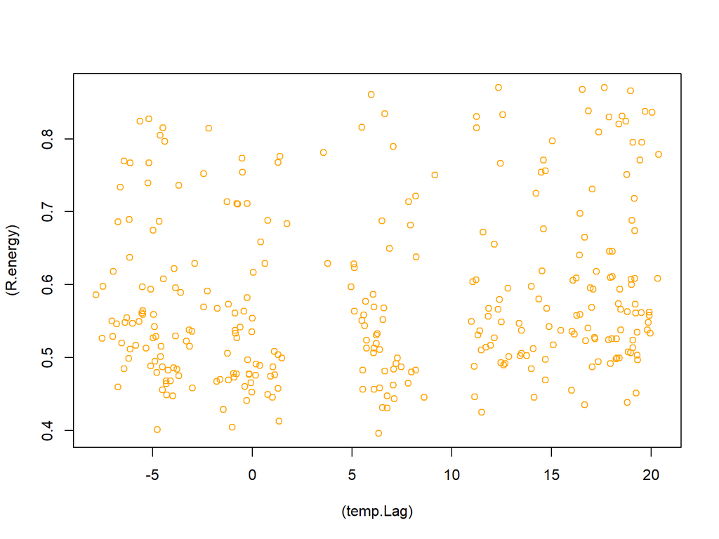

```
## [1] 0.04380822
```

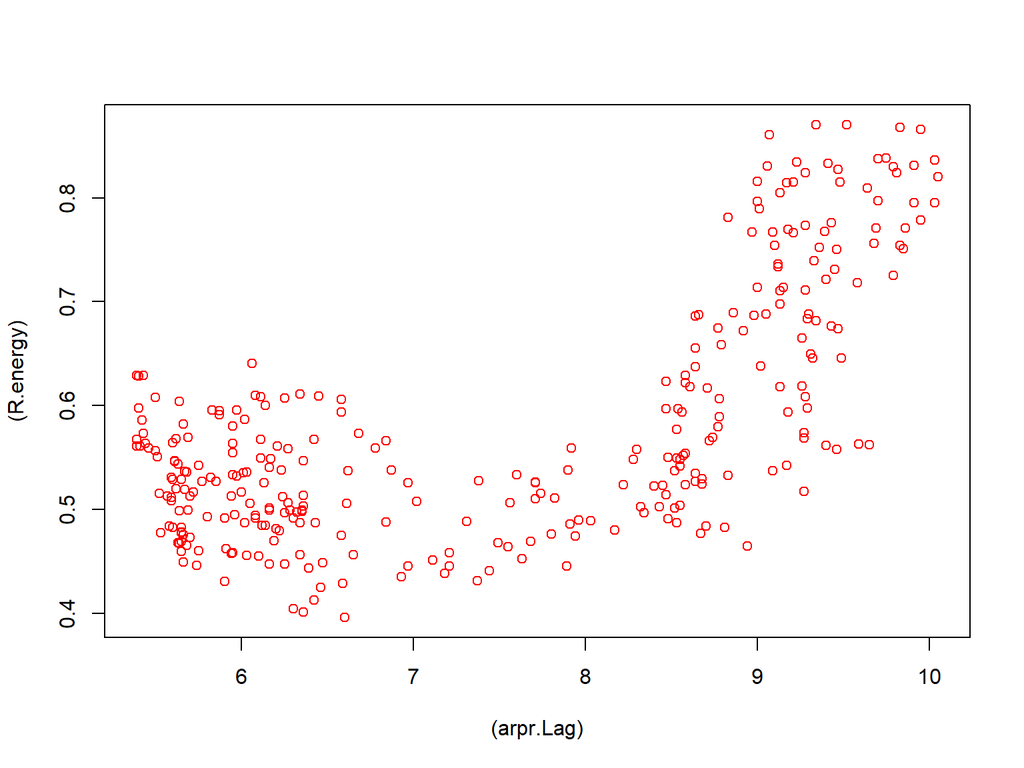

```
## [1] 0.6435921
```

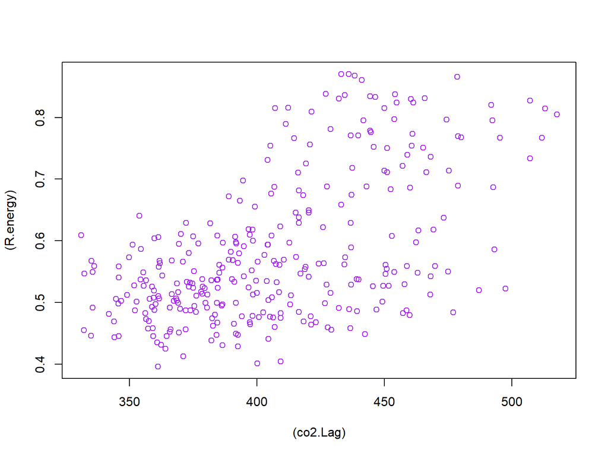

```
## [1] 0.620392
```

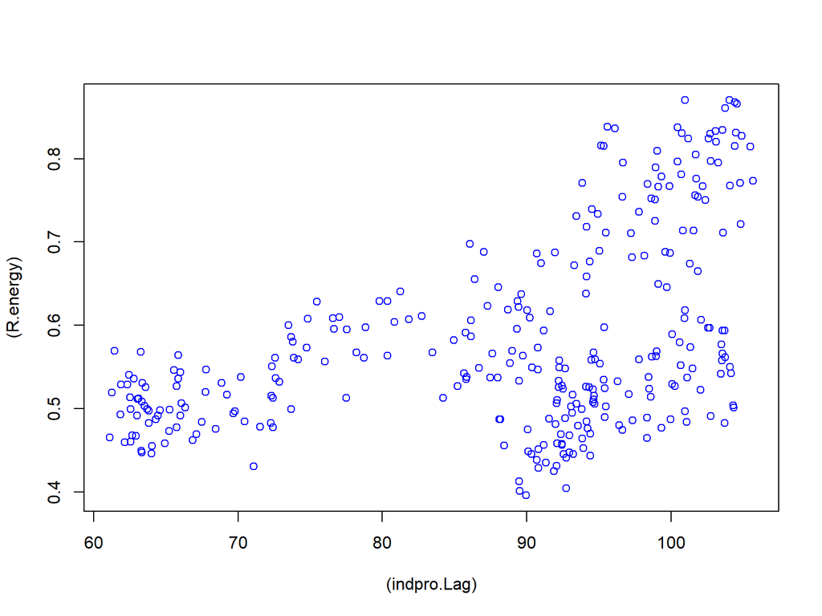

```
## [1] 0.4713404
```

```
##
## Call:
## lm(formula = r.energy ~ indpro.Lag + arpr.Lag + temp.Lag + co2.Lag,
##     data = Train)
##
## Residuals:
##       Min        1Q    Median        3Q       Max
## -0.158433 -0.054008 -0.008198  0.052001  0.203636
##
## Coefficients:
##               Estimate Std. Error t value Pr(>|t|)
## (Intercept) -0.1687549  0.0648330  -2.603  0.00972 **
## indpro.Lag  -0.0006799  0.0005666  -1.200  0.23112
## arpr.Lag     0.0290555  0.0061502   4.724 3.60e-06 ***
## temp.Lag     0.0038672  0.0007097   5.449 1.08e-07 ***
## co2.Lag      0.0013827  0.0001707   8.099 1.55e-14 ***
## ---
## Signif. codes:  0 '***' 0.001 '**' 0.01 '*' 0.05 '.' 0.1 ' ' 1
##
## Residual standard error: 0.07497 on 290 degrees of freedom
## Multiple R-squared:  0.5192, Adjusted R-squared:  0.5126
## F-statistic: 78.29 on 4 and 290 DF,  p-value: < 2.2e-16
```

We can see that from the results above our regression model coefficients are siginifcant at 0.05 siginificance level , but we see at the same time that coefficient for the industrial production index it is not significant since p-value =0.23112, which is bigger than 0.05. Before we move further and we accept this model , we want to make sure to check if we have satifisfied our multilinear regression assumption and if the residuals are white noise.

## Residual and assumption check

```
##
##  Durbin-Watson test
##
## data:  reg
## DW = 0.62457, p-value < 2.2e-16
## alternative hypothesis: true autocorrelation is greater than 0
```

```
## indpro.Lag   arpr.Lag   temp.Lag    co2.Lag
##   2.995308   4.428846   2.194310   2.413739
```

```
##
##  Box-Ljung test
##
## data:  residuals
## X-squared = 1736.4, df = 24, p-value < 2.2e-16
```

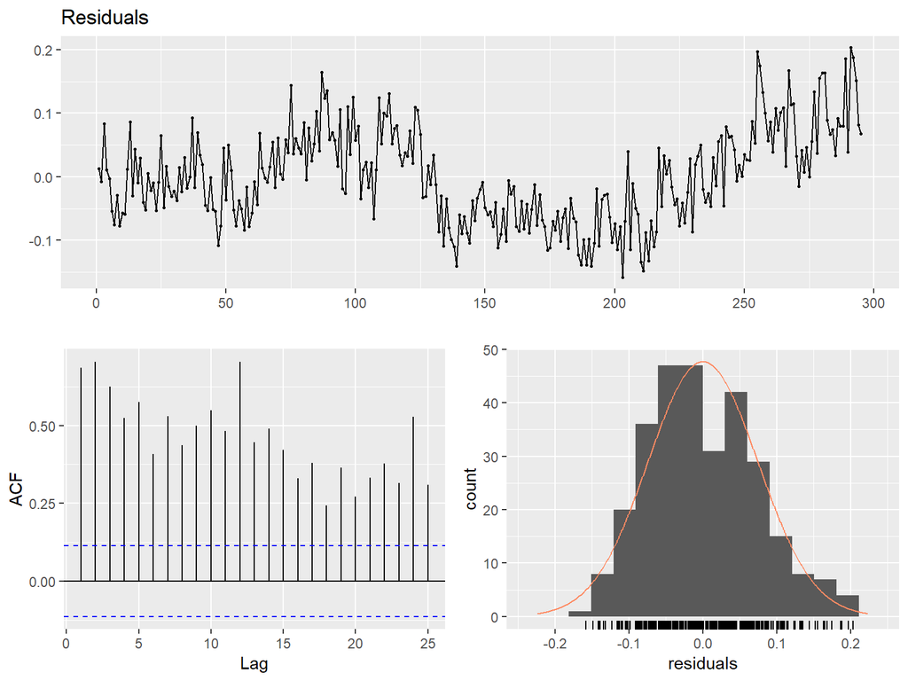

We can see that with the results that we get from the Durbin-Watson test, our P-value is very small which means that we reject the null hypothesis in favor of alternative hypothesis , so there is serial autocorrelation in our model. Another way we can see that is by looking at the AFC for the residuals where can see that the AFC plot does not really die off, at the same time our residuals are not normally distributed and if we look at their plot we can even see almost a trend. VIF test tells us about the multicolinearity, since all of our VIF levels for the variables are less then 10 , then we can say that there is not a lot of multicolinearity that influences our model. However another failure of our regression model is that when look at the test for the white noise of the residuals, our residuals are not white noise , so that means that we cannot trust our model and that we will need to adjust it.

## Correcting the Regression model

- Since we have residual autocorrelation we correct our regression model

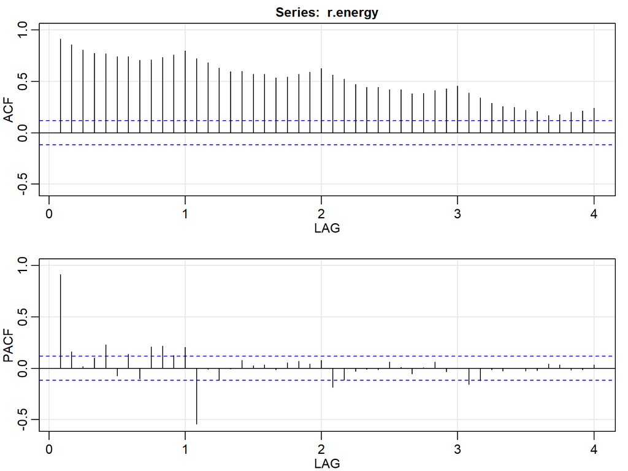

```
##        ACF  PACF
##  [1,] 0.91  0.91
##  [2,] 0.86  0.16
##  [3,] 0.80  0.02
##  [4,] 0.77  0.10
##  [5,] 0.77  0.23
##  [6,] 0.74 -0.07
##  [7,] 0.74  0.14
##  [8,] 0.70 -0.10
##  [9,] 0.71  0.21
## [10,] 0.73  0.22
## [11,] 0.76  0.13
## [12,] 0.80  0.20
## [13,] 0.72 -0.54
## [14,] 0.68 -0.01
```

[output cut: 34 more lines]

```
##
##  Augmented Dickey-Fuller Test
##
## data:  r.energy
## Dickey-Fuller = -1.5962, Lag order = 6, p-value = 0.7464
## alternative hypothesis: stationary
```

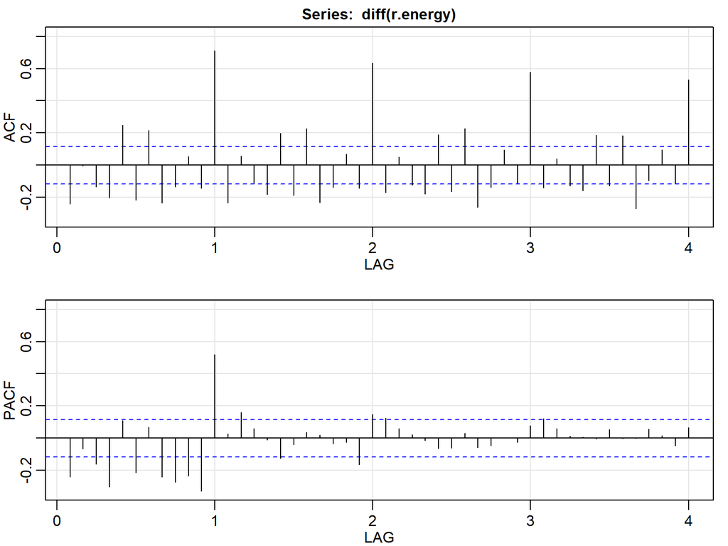

```
##         ACF  PACF
##  [1,] -0.24 -0.24
##  [2,]  0.00 -0.07
##  [3,] -0.13 -0.16
##  [4,] -0.20 -0.30
##  [5,]  0.25  0.11
##  [6,] -0.22 -0.22
##  [7,]  0.22  0.07
##  [8,] -0.24 -0.24
##  [9,] -0.13 -0.27
## [10,]  0.05 -0.23
## [11,] -0.15 -0.33
## [12,]  0.71  0.52
## [13,] -0.24  0.03
## [14,]  0.06  0.16
```

[output cut: 34 more lines]

```
##
##  Augmented Dickey-Fuller Test
##
## data:  diff(r.energy)
## Dickey-Fuller = -8.1698, Lag order = 6, p-value = 0.01
## alternative hypothesis: stationary
```

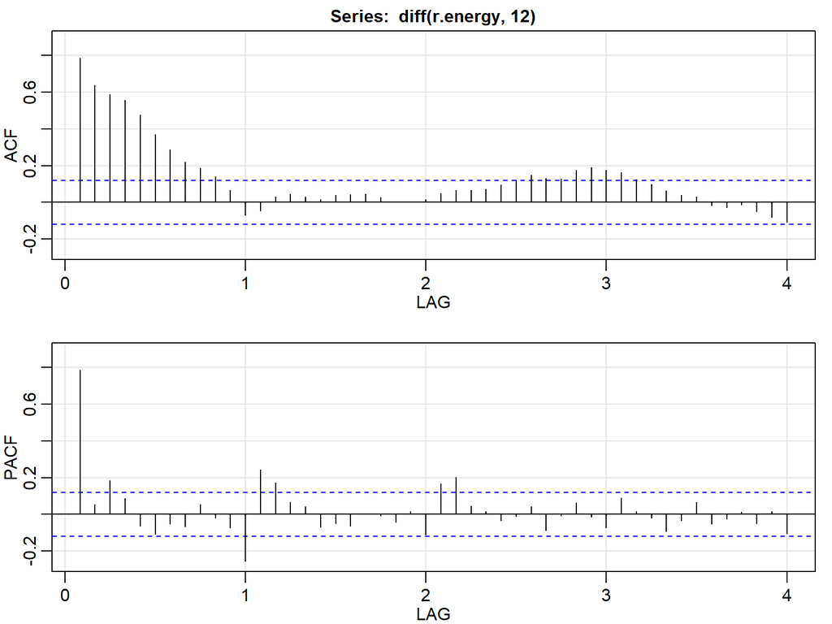

```
##         ACF  PACF
##  [1,]  0.79  0.79
##  [2,]  0.64  0.05
##  [3,]  0.59  0.18
##  [4,]  0.55  0.09
##  [5,]  0.47 -0.06
##  [6,]  0.37 -0.11
##  [7,]  0.29 -0.05
##  [8,]  0.22 -0.07
##  [9,]  0.19  0.06
## [10,]  0.14 -0.02
## [11,]  0.07 -0.07
## [12,] -0.07 -0.26
## [13,] -0.04  0.24
## [14,]  0.03  0.17
```

[output cut: 34 more lines]

We can see from acf and pacf plots that the data is not stationary, even after we take the first difference we still see seasonality in the acf plot for this reason we decide to take the first seasonal diifference. To adjust the regression model we will sarima with code below.

```
## Series: r.energy
## ARIMA(3,1,0)(0,1,1)[12]
##
## Coefficients:
##           ar1      ar2      ar3     sma1
##       -0.2990  -0.3034  -0.1205  -0.7318
## s.e.   0.0603   0.0601   0.0602   0.0492
##
## sigma^2 estimated as 0.0005555:  log likelihood=654.04
## AIC=-1298.09   AICc=-1297.87   BIC=-1279.88
```

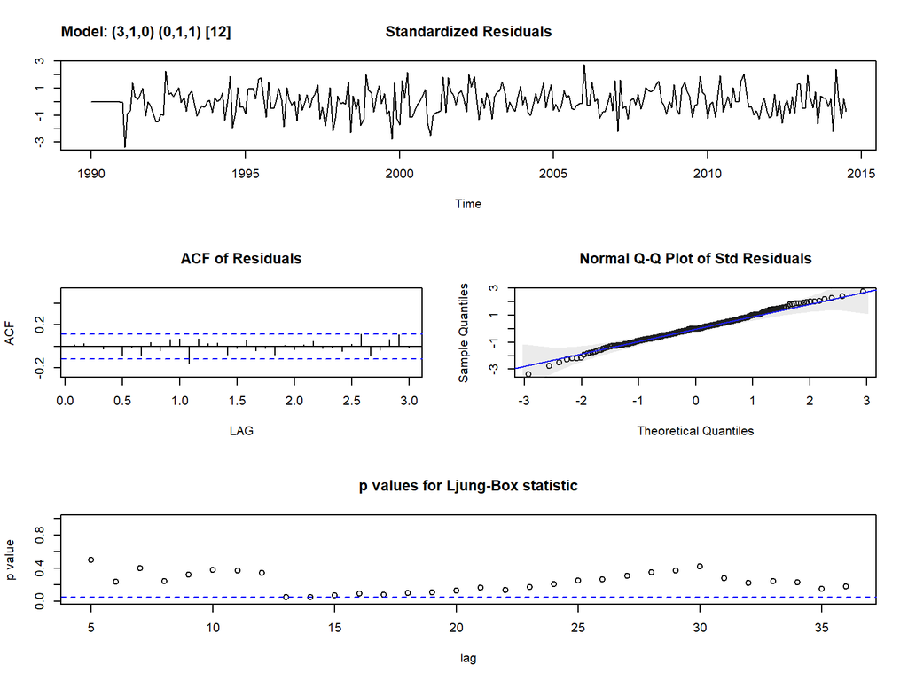

```
##  [1] "$fit"
##  [2] ""
##  [3] "Call:"
##  [4] "stats::arima(x = xdata, order = c(p, d, q), seasonal = list(order = c(P, D, "
##  [5] "    Q), period = S), xreg = xreg, optim.control = list(trace = trc, REPORT = 1, "
##  [6] "    reltol = tol))"
##  [7] ""
##  [8] "Coefficients:"
##  [9] "          ar1      ar2      ar3     sma1  indpro.Lag  arpr.Lag  temp.Lag"
## [10] "      -0.2924  -0.3067  -0.1213  -0.7311      0.0019   -0.0068   -0.0007"
## [11] "s.e.   0.0608   0.0603   0.0606   0.0496      0.0017    0.0162    0.0014"
## [12] "      co2.Lag"
## [13] "        1e-04"
## [14] "s.e.    1e-04"
## [15] ""
```

[output cut: 25 more lines]

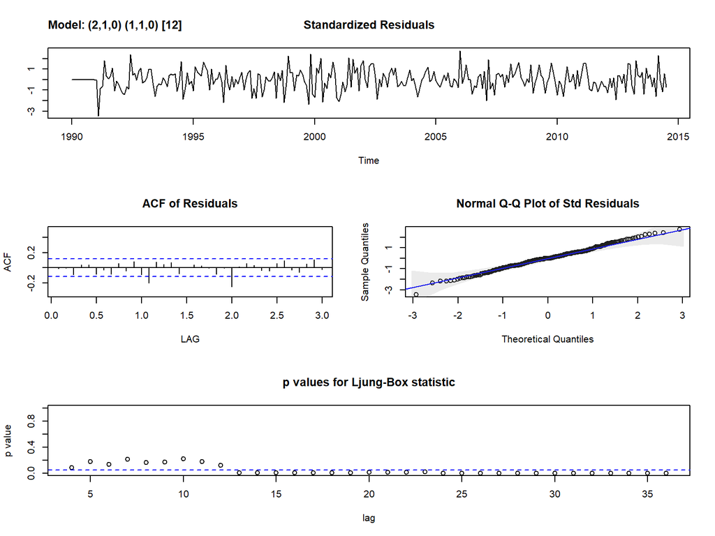

```
##  [1] "$fit"
##  [2] ""
##  [3] "Call:"
##  [4] "stats::arima(x = xdata, order = c(p, d, q), seasonal = list(order = c(P, D, "
##  [5] "    Q), period = S), xreg = xreg, optim.control = list(trace = trc, REPORT = 1, "
##  [6] "    reltol = tol))"
##  [7] ""
##  [8] "Coefficients:"
##  [9] "          ar1      ar2     sar1  indpro.Lag  arpr.Lag  temp.Lag  co2.Lag"
## [10] "      -0.2367  -0.2660  -0.4290      0.0025   -0.0019   -0.0006    0e+00"
## [11] "s.e.   0.0599   0.0591   0.0569      0.0018    0.0174    0.0013    1e-04"
## [12] ""
## [13] "sigma^2 estimated as 0.0006587:  log likelihood = 631.41,  aic = -1246.81"
## [14] ""
## [15] "$degrees_of_freedom"
```

[output cut: 21 more lines]

We choose two sarima models to fercast and adjust the regression model. The residuals are not bad, they are almos white noise overall. The first model we choose it with auto.arima code and the second model we choose by analyzing the PACF and ACF graph. Looking where the lags cut we choose to forecast the model Arima (2,1,0)(1,1,0)(12). We can see that the AIC and BIC for both models is vert small which means they are a good fit. Something that we keep in mind when we see this model is that while our autocorrelation coefficients and moving averages are significant in both models , we see that the coefficients for the dependent variables are not siginficant , because their p-value is bigger than siginificance level 0.05 which means that they are 0 and do not help our model at all overall. Below we will try to see how good our two seasonal sarima models are at forecasting. In the first model that we choose our selves the residuals are still not white noise while on the autoarima the residuals are white noise.

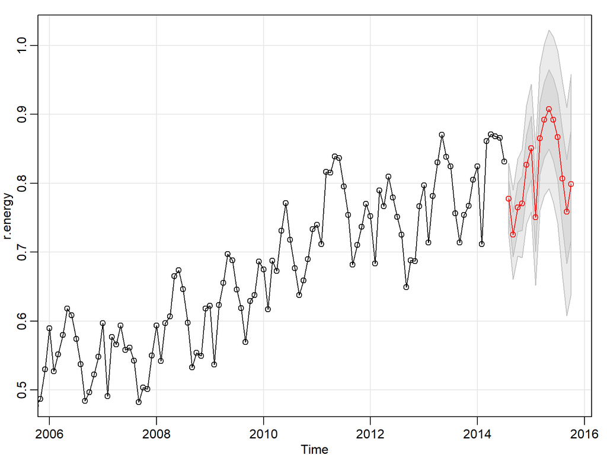

```
##                   ME       RMSE        MAE       MPE     MAPE      ACF1
## Test set -0.02175418 0.04183098 0.03116216 -2.670234 3.849086 0.5943748
##          Theil's U
## Test set  1.115643
```

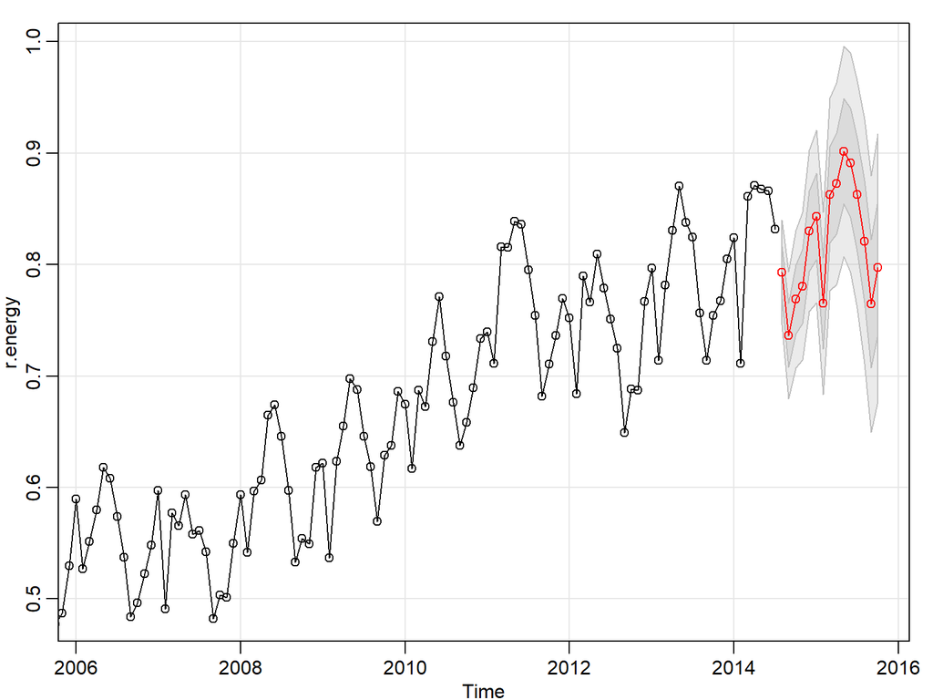

```
##                   ME       RMSE        MAE       MPE     MAPE     ACF1
## Test set -0.02417106 0.03864558 0.02973641 -3.005264 3.695058 0.622267
##          Theil's U
## Test set  1.019957
```

We can see that the mape values are respectively around 3.85 and 3.70, which means that our models have a good forecasting power since , the mape number represent the error that we will have in our predicted data. The next step is too predict the data using exponential forecasting.

## Exponential Model

```
## Subset selection object
## Call: regsubsets.formula(r.energy ~ ., all, nvmax = 20, method = "forward")
## 6 Variables  (and intercept)
##       Forced in Forced out
## `t^1`     FALSE      FALSE
## `t^2`     FALSE      FALSE
## `t^3`     FALSE      FALSE
## `t^4`     FALSE      FALSE
## `t^5`     FALSE      FALSE
## `t^6`     FALSE      FALSE
## 1 subsets of each size up to 6
## Selection Algorithm: forward
##          `t^1` `t^2` `t^3` `t^4` `t^5` `t^6`
## 1  ( 1 ) " "   " "   " "   " "   "*"   " "
## 2  ( 1 ) " "   "*"   " "   " "   "*"   " "
## 3  ( 1 ) " "   "*"   " "   " "   "*"   "*"
## 4  ( 1 ) " "   "*"   "*"   " "   "*"   "*"
## 5  ( 1 ) " "   "*"   "*"   "*"   "*"   "*"
## 6  ( 1 ) "*"   "*"   "*"   "*"   "*"   "*"
```

```
## [1] 6
```

```
## [1] 6
```

```
## [1] 6
```

In the simple exponential model we choose six models from power 6 to power 1 and , we test all of them on the fitness of the model. As we can see from the rezults the model that is best fitted to represent our data is model 6.

## Analysis of exponential model

```
##
## Call:
## lm(formula = r.energy ~ ., data = all)
##
## Residuals:
##      Min       1Q   Median       3Q      Max
## -0.11494 -0.03318 -0.00051  0.03412  0.11773
##
## Coefficients:
##               Estimate Std. Error t value Pr(>|t|)
## (Intercept)  5.589e-01  1.927e-02  29.001  < 2e-16 ***
## `t^1`       -9.022e-03  1.789e-03  -5.044 8.10e-07 ***
## `t^2`        3.256e-04  5.233e-05   6.222 1.72e-09 ***
## `t^3`       -4.256e-06  6.619e-07  -6.429 5.30e-10 ***
## `t^4`        2.494e-08  4.061e-09   6.142 2.69e-09 ***
## `t^5`       -6.700e-11  1.191e-11  -5.627 4.34e-08 ***
## `t^6`        6.772e-14  1.336e-14   5.068 7.21e-07 ***
## ---
## Signif. codes:  0 '***' 0.001 '**' 0.01 '*' 0.05 '.' 0.1 ' ' 1
##
## Residual standard error: 0.04538 on 288 degrees of freedom
## Multiple R-squared:  0.825,  Adjusted R-squared:  0.8214
## F-statistic: 226.4 on 6 and 288 DF,  p-value: < 2.2e-16
```

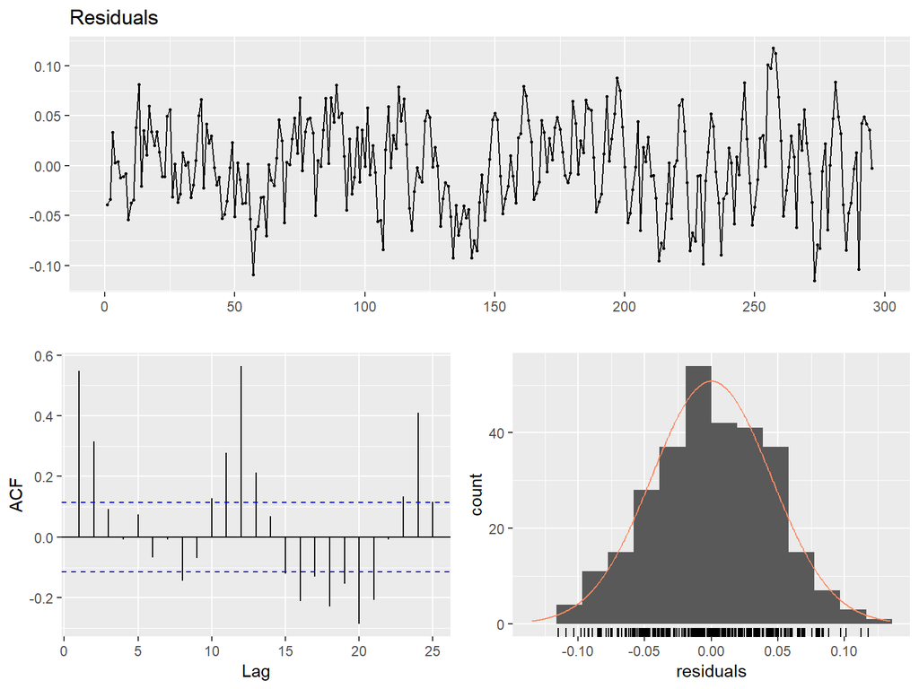

```
##
##  Breusch-Godfrey test for serial correlation of order up to 10
##
## data:  Residuals
## LM test = 130.37, df = 10, p-value < 2.2e-16
```

```
##
##  Box-Ljung test
##
## data:  residuals1
## X-squared = 423.06, df = 24, p-value < 2.2e-16
```

```
##                 ME     RMSE       MAE      MPE     MAPE      ACF1
## Test set 0.2852875 0.288602 0.2852875 35.73217 35.73217 0.5814007
##          Theil's U
## Test set  7.738729
```

```
## [1] -978.6074
```

```
## [1] -949.1116
```

```
##
## Forecast method: Simple exponential smoothing
##
## Model Information:
## Simple exponential smoothing
##
## Call:
##  ses(y = Train[, 1], h = 15)
##
##   Smoothing parameters:
##     alpha = 0.6724
##
##   Initial states:
##     l = 0.5151
##
##   sigma:  0.0412
##
##       AIC      AICc       BIC
## -199.8019 -199.7195 -188.7410
##
## Error measures:
##                       ME      RMSE        MAE       MPE     MAPE      MASE
## Training set 0.001650539 0.0410771 0.03321246 -0.097443 5.865904 0.8919378
##                    ACF1
## Training set 0.04443668
##
## Forecasts:
##          Point Forecast     Lo 80     Hi 80     Lo 95     Hi 95
## Aug 2014       0.842517 0.7896952 0.8953388 0.7617331 0.9233009
## Sep 2014       0.842517 0.7788650 0.9061690 0.7451697 0.9398643
## Oct 2014       0.842517 0.7696266 0.9154074 0.7310408 0.9539932
## Nov 2014       0.842517 0.7614341 0.9235999 0.7185114 0.9665226
## Dec 2014       0.842517 0.7539965 0.9310375 0.7071366 0.9778974
## Jan 2015       0.842517 0.7471372 0.9378968 0.6966462 0.9883878
## Feb 2015       0.842517 0.7407391 0.9442949 0.6868611 0.9981729
## Mar 2015       0.842517 0.7347201 0.9503139 0.6776559 1.0073781
## Apr 2015       0.842517 0.7290198 0.9560142 0.6689381 1.0160959
## May 2015       0.842517 0.7235925 0.9614415 0.6606377 1.0243963
## Jun 2015       0.842517 0.7184022 0.9666318 0.6526999 1.0323341
## Jul 2015       0.842517 0.7134205 0.9716135 0.6450809 1.0399531
## Aug 2015       0.842517 0.7086240 0.9764100 0.6377453 1.0472887
## Sep 2015       0.842517 0.7039935 0.9810405 0.6306635 1.0543705
## Oct 2015       0.842517 0.6995128 0.9855212 0.6238109 1.0612231
```

```
##
## Forecast method: Holt's method
##
## Model Information:
## Holt's method
##
## Call:
##  holt(y = Train[, 1], h = 15)
##
##   Smoothing parameters:
##     alpha = 0.6719
##     beta  = 1e-04
##
##   Initial states:
##     l = 0.5208
##     b = 0.0011
##
##   sigma:  0.0413
##
##       AIC      AICc       BIC
## -196.2033 -195.9956 -177.7684
##
## Error measures:
##                        ME       RMSE        MAE        MPE    MAPE
## Training set 7.266982e-05 0.04104917 0.03316186 -0.3829258 5.87129
##                   MASE       ACF1
## Training set 0.8905789 0.04484937
##
## Forecasts:
##          Point Forecast     Lo 80     Hi 80     Lo 95     Hi 95
## Aug 2014      0.8441132 0.7911463 0.8970802 0.7631073 0.9251192
## Sep 2014      0.8451744 0.7813602 0.9089886 0.7475790 0.9427698
## Oct 2014      0.8462356 0.7731645 0.9193067 0.7344830 0.9579882
## Nov 2014      0.8472968 0.7660140 0.9285795 0.7229855 0.9716081
## Dec 2014      0.8483579 0.7596180 0.9370979 0.7126419 0.9840740
## Jan 2015      0.8494191 0.7537999 0.9450384 0.7031821 0.9956561
## Feb 2015      0.8504803 0.7484427 0.9525179 0.6944272 1.0065334
## Mar 2015      0.8515415 0.7434642 0.9596188 0.6862516 1.0168314
## Apr 2015      0.8526027 0.7388042 0.9664011 0.6785629 1.0266424
## May 2015      0.8536638 0.7344168 0.9729109 0.6712912 1.0360365
## Jun 2015      0.8547250 0.7302661 0.9791839 0.6643816 1.0450685
## Jul 2015      0.8557862 0.7263237 0.9852487 0.6577904 1.0537820
## Aug 2015      0.8568474 0.7225662 0.9911286 0.6514820 1.0622128
## Sep 2015      0.8579086 0.7189743 0.9968428 0.6454269 1.0703902
## Oct 2015      0.8589697 0.7155320 1.0024075 0.6396006 1.0783389
```

```
##
## Forecast method: Holt-Winters' additive method
##
## Model Information:
## Holt-Winters' additive method
##
## Call:
##  hw(y = Train[, 1], h = 15, seasonal = "additive")
##
##   Smoothing parameters:
##     alpha = 0.4547
##     beta  = 1e-04
##     gamma = 0.337
##
##   Initial states:
##     l = 0.4966
##     b = 0.0013
##     s = 0.027 -0.0251 -0.0264 -0.0308 -0.021 -0.0067
##            0.0081 0.0271 0 0.0333 -0.0208 0.0353
##
##   sigma:  0.0247
##
##       AIC      AICc       BIC
## -488.1533 -485.9439 -425.4747
##
## Error measures:
##                         ME       RMSE        MAE        MPE     MAPE
## Training set -0.0003769011 0.02402901 0.01887905 -0.2653761 3.437163
##                   MASE      ACF1
## Training set 0.5070067 0.2060674
##
## Forecasts:
##          Point Forecast     Lo 80     Hi 80     Lo 95     Hi 95
## Aug 2014      0.7860734 0.7544083 0.8177385 0.7376458 0.8345010
## Sep 2014      0.7339128 0.6991261 0.7686995 0.6807111 0.7871145
## Oct 2014      0.7709835 0.7333318 0.8086352 0.7134001 0.8285668
## Nov 2014      0.7826450 0.7423301 0.8229599 0.7209887 0.8443014
## Dec 2014      0.8317300 0.7889160 0.8745439 0.7662517 0.8972082
## Jan 2015      0.8442004 0.7990244 0.8893765 0.7751096 0.9132912
## Feb 2015      0.7585648 0.7111431 0.8059866 0.6860396 0.8310901
## Mar 2015      0.8703740 0.8208072 0.9199408 0.7945682 0.9461799
## Apr 2015      0.8734523 0.8218285 0.9250761 0.7945005 0.9524041
## May 2015      0.8894241 0.8358213 0.9430270 0.8074456 0.9714026
## Jun 2015      0.8774595 0.8219472 0.9329719 0.7925608 0.9623583
## Jul 2015      0.8476168 0.7902576 0.9049760 0.7598935 0.9353401
## Aug 2015      0.8013287 0.7387127 0.8639447 0.7055659 0.8970916
## Sep 2015      0.7491681 0.6849076 0.8134287 0.6508901 0.8474461
## Oct 2015      0.7862388 0.7203740 0.8521037 0.6855072 0.8869704
```

```
##
## Forecast method: Holt-Winters' multiplicative method
##
## Model Information:
## Holt-Winters' multiplicative method
##
## Call:
##  hw(y = Train[, 1], h = 15, seasonal = "multiplicative")
##
##   Smoothing parameters:
##     alpha = 0.5458
##     beta  = 1e-04
##     gamma = 0.1834
##
##   Initial states:
##     l = 0.465
##     b = 0.001
##     s = 1.0159 0.9235 0.929 0.9024 0.9795 1.0126
##            1.0144 1.0493 1.0431 1.0886 0.9743 1.0675
##
##   sigma:  0.0429
##
##       AIC      AICc       BIC
## -502.2775 -500.0681 -439.5989
##
## Error measures:
##                        ME       RMSE       MAE        MPE     MAPE
## Training set 0.0003037774 0.02285202 0.0180374 -0.1044267 3.260749
##                   MASE     ACF1
## Training set 0.4844037 0.142436
##
## Forecasts:
##          Point Forecast     Lo 80     Hi 80     Lo 95     Hi 95
## Aug 2014      0.7837737 0.7406345 0.8269129 0.7177981 0.8497494
## Sep 2014      0.7174906 0.6725009 0.7624804 0.6486847 0.7862965
## Oct 2014      0.7492336 0.6971477 0.8013195 0.6695751 0.8288921
## Nov 2014      0.7578962 0.7005130 0.8152793 0.6701362 0.8456561
## Dec 2014      0.8142386 0.7479347 0.8805424 0.7128356 0.9156415
## Jan 2015      0.8312164 0.7590969 0.9033358 0.7209191 0.9415136
## Feb 2015      0.7481119 0.6794498 0.8167739 0.6431023 0.8531214
## Mar 2015      0.8557201 0.7731174 0.9383227 0.7293902 0.9820499
## Apr 2015      0.8568490 0.7702643 0.9434336 0.7244292 0.9892688
## May 2015      0.8889051 0.7952409 0.9825692 0.7456581 1.0321521
## Jun 2015      0.8778421 0.7817059 0.9739783 0.7308144 1.0248698
## Jul 2015      0.8440339 0.7482349 0.9398329 0.6975220 0.9905458
## Aug 2015      0.7953242 0.6996325 0.8910158 0.6489764 0.9416720
## Sep 2015      0.7280516 0.6378102 0.8182931 0.5900393 0.8660640
## Oct 2015      0.7602487 0.6633381 0.8571593 0.6120367 0.9084606
```

```
##                        ME       RMSE        MAE       MPE     MAPE
## Training set  0.001650539 0.04107710 0.03321246 -0.097443 5.865904
## Test set     -0.047359267 0.05765799 0.04735927 -6.142473 6.142473
##                   MASE       ACF1 Theil's U
## Training set 0.8919378 0.04443668        NA
## Test set     1.2718577 0.38729153  1.530647
```

```
##                         ME       RMSE        MAE        MPE     MAPE
## Training set  7.266982e-05 0.04104917 0.03316186 -0.3829258 5.871290
## Test set     -5.638375e-02 0.06505701 0.05638375 -7.2751218 7.275122
##                   MASE       ACF1 Theil's U
## Training set 0.8905789 0.04484937        NA
## Test set     1.5142149 0.36979528  1.738464
```

```
##                         ME       RMSE        MAE        MPE     MAPE
## Training set -0.0003769011 0.02402901 0.01887905 -0.2653761 3.437163
## Test set     -0.0183870910 0.03313393 0.02438516 -2.2664441 3.015556
##                   MASE      ACF1 Theil's U
## Training set 0.5070067 0.2060674        NA
## Test set     0.6548762 0.5085126  0.878154
```

```
##                         ME       RMSE        MAE        MPE     MAPE
## Training set  0.0003037774 0.02285202 0.01803740 -0.1044267 3.260749
## Test set     -0.0054379668 0.03412548 0.02653525 -0.6258706 3.306304
##                   MASE      ACF1 Theil's U
## Training set 0.4844037 0.1424360        NA
## Test set     0.7126180 0.5784929 0.9168991
```

The best model that we get is the model with exponential smoothing with trend and additive seasonality. The mape for this model is 3.01, but the only problem that we might get with this model is that if we are too look at the AIC and BIC values they are respectively -488.1533, -425.4747, which is very big. Next we will move to out sarima model. This time we can look at the difference afc and pacf one more time.

## Sarima

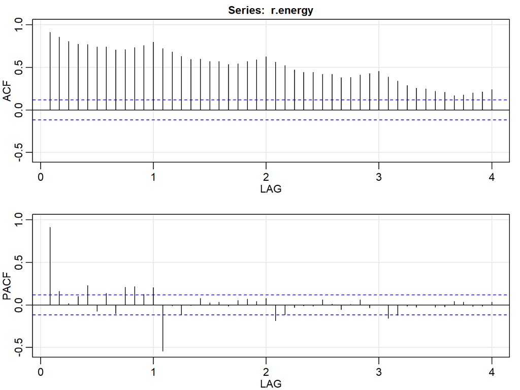

```
##        ACF  PACF
##  [1,] 0.91  0.91
##  [2,] 0.86  0.16
##  [3,] 0.80  0.02
##  [4,] 0.77  0.10
##  [5,] 0.77  0.23
##  [6,] 0.74 -0.07
##  [7,] 0.74  0.14
##  [8,] 0.70 -0.10
##  [9,] 0.71  0.21
## [10,] 0.73  0.22
## [11,] 0.76  0.13
## [12,] 0.80  0.20
## [13,] 0.72 -0.54
## [14,] 0.68 -0.01
```

[output cut: 34 more lines]

```
##
##  Augmented Dickey-Fuller Test
##
## data:  r.energy
## Dickey-Fuller = -1.5962, Lag order = 6, p-value = 0.7464
## alternative hypothesis: stationary
```

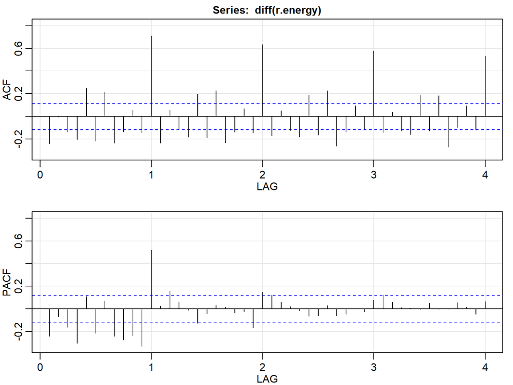

```
##         ACF  PACF
##  [1,] -0.24 -0.24
##  [2,]  0.00 -0.07
##  [3,] -0.13 -0.16
##  [4,] -0.20 -0.30
##  [5,]  0.25  0.11
##  [6,] -0.22 -0.22
##  [7,]  0.22  0.07
##  [8,] -0.24 -0.24
##  [9,] -0.13 -0.27
## [10,]  0.05 -0.23
## [11,] -0.15 -0.33
## [12,]  0.71  0.52
## [13,] -0.24  0.03
## [14,]  0.06  0.16
```

[output cut: 34 more lines]

```
##
##  Augmented Dickey-Fuller Test
##
## data:  diff(r.energy)
## Dickey-Fuller = -8.1698, Lag order = 6, p-value = 0.01
## alternative hypothesis: stationary
```

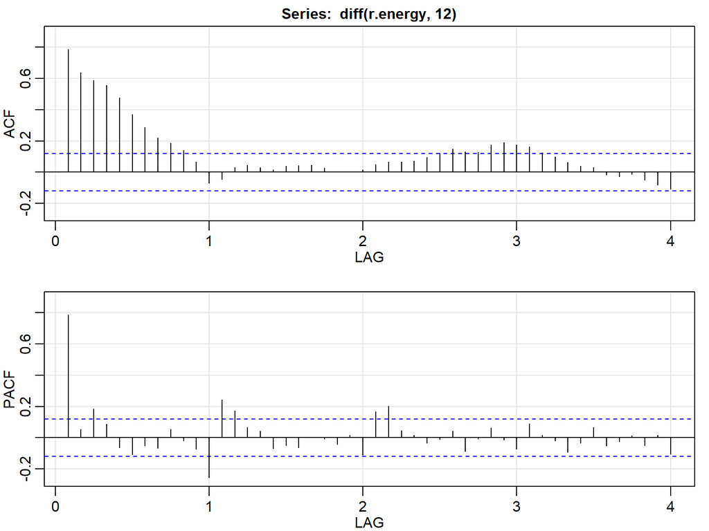

```
##         ACF  PACF
##  [1,]  0.79  0.79
##  [2,]  0.64  0.05
##  [3,]  0.59  0.18
##  [4,]  0.55  0.09
##  [5,]  0.47 -0.06
##  [6,]  0.37 -0.11
##  [7,]  0.29 -0.05
##  [8,]  0.22 -0.07
##  [9,]  0.19  0.06
## [10,]  0.14 -0.02
## [11,]  0.07 -0.07
## [12,] -0.07 -0.26
## [13,] -0.04  0.24
## [14,]  0.03  0.17
```

[output cut: 34 more lines]

Since we have analyzed the seasonality of our time series variable and we have already the parameters for the sarima models when we adjusted the regression model we can just go ahead and write the code for the sarima models below.

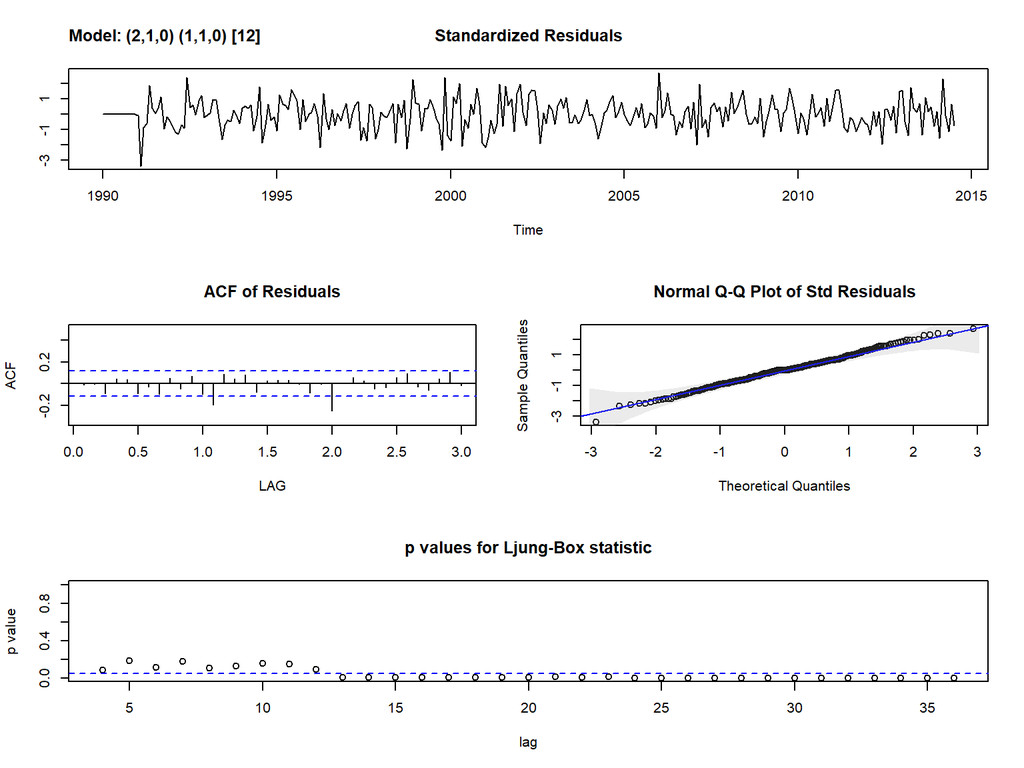

```
##  [1] "$fit"
##  [2] ""
##  [3] "Call:"
##  [4] "stats::arima(x = xdata, order = c(p, d, q), seasonal = list(order = c(P, D, "
##  [5] "    Q), period = S), include.mean = !no.constant, optim.control = list(trace = trc, "
##  [6] "    REPORT = 1, reltol = tol))"
##  [7] ""
##  [8] "Coefficients:"
##  [9] "          ar1      ar2     sar1"
## [10] "      -0.2444  -0.2627  -0.4297"
## [11] "s.e.   0.0594   0.0588   0.0566"
## [12] ""
## [13] "sigma^2 estimated as 0.0006642:  log likelihood = 630.24,  aic = -1252.48"
## [14] ""
## [15] "$degrees_of_freedom"
```

[output cut: 17 more lines]

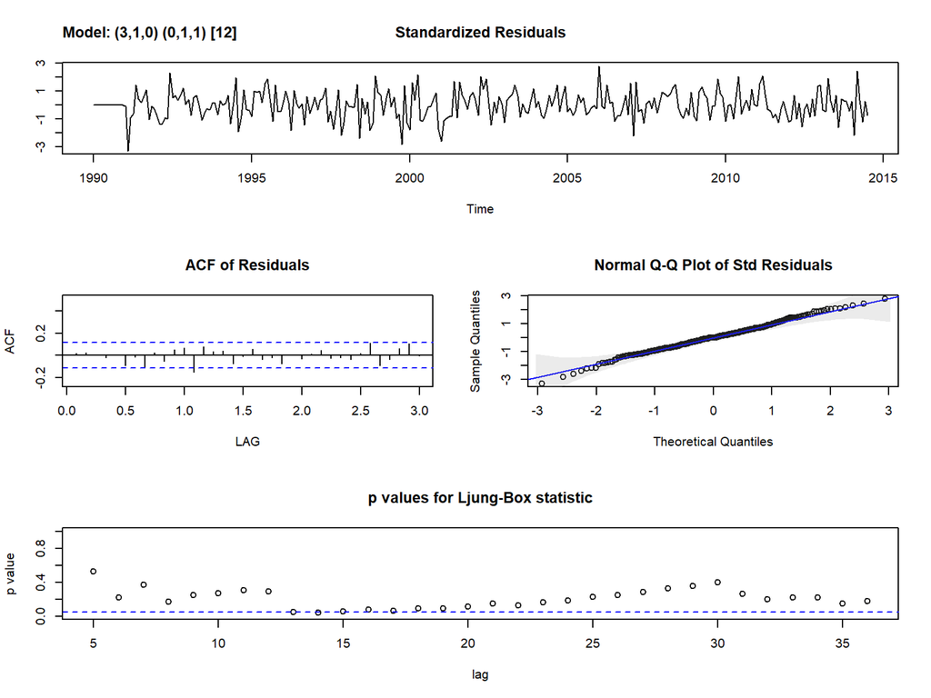

```
##  [1] "$fit"
##  [2] ""
##  [3] "Call:"
##  [4] "stats::arima(x = xdata, order = c(p, d, q), seasonal = list(order = c(P, D, "
##  [5] "    Q), period = S), include.mean = !no.constant, optim.control = list(trace = trc, "
##  [6] "    REPORT = 1, reltol = tol))"
##  [7] ""
##  [8] "Coefficients:"
##  [9] "          ar1      ar2      ar3     sma1"
## [10] "      -0.2990  -0.3034  -0.1205  -0.7318"
## [11] "s.e.   0.0603   0.0601   0.0602   0.0492"
## [12] ""
## [13] "sigma^2 estimated as 0.0005476:  log likelihood = 654.04,  aic = -1298.09"
## [14] ""
## [15] "$degrees_of_freedom"
```

[output cut: 18 more lines]

The results do not change from the part where we dealt with the adjusted regression since what we are seeing now is the same model,because for the adjusted regression all of our other coefficients were not significant. Again we can see that the model that we have choosen Arima (2,1,0) (1,1,0) (12), doesn’t have white noise residuals while the autorima model performs better on this issue. The next step is to view the forecasting power of the models. ## Accuracy of Sarima Models Forecasting Power

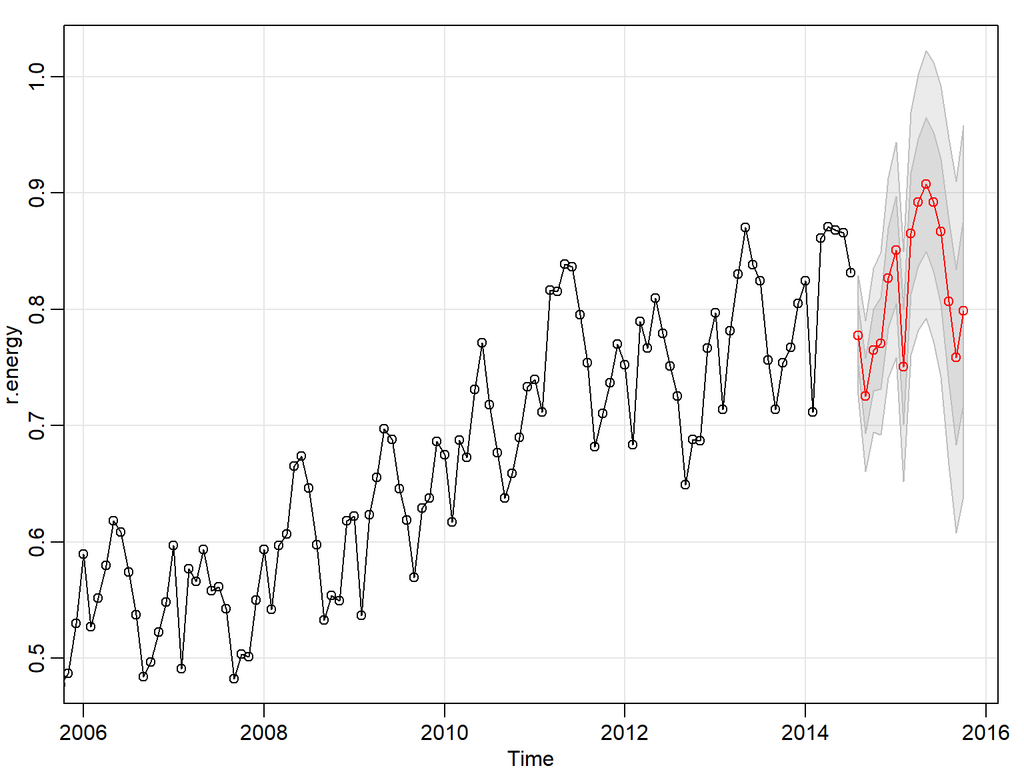

```
##                   ME       RMSE        MAE       MPE     MAPE      ACF1
## Test set -0.02175418 0.04183098 0.03116216 -2.670234 3.849086 0.5943748
##          Theil's U
## Test set  1.115643
```

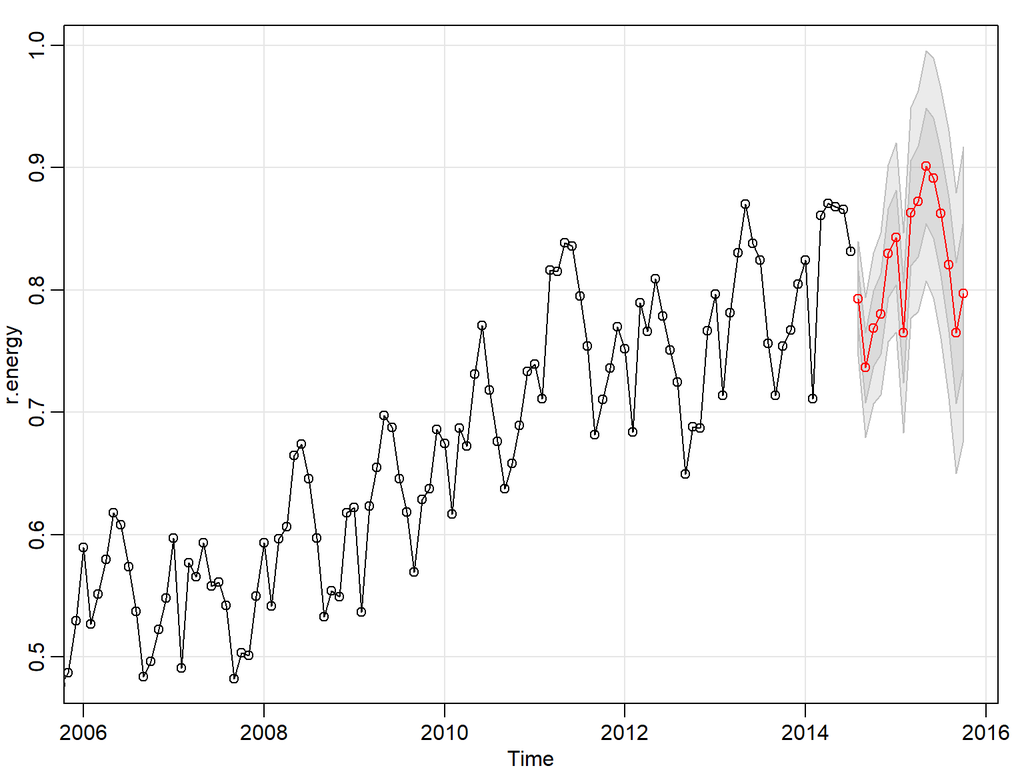

```
##                   ME       RMSE        MAE       MPE     MAPE      ACF1
## Test set -0.02425008 0.03869085 0.02978396 -3.015321 3.701097 0.6222322
##          Theil's U
## Test set  1.021155
```

Again Mape doesn’t not change, we have mape=3.85 almost for the first model that we choose ourselves and for the second model that we choose ourselves we have mape=3.7 which means the second model has better forecasting power. However our model is not a better fit than the autarima at the same time. The AIC and BIC of our model respectively are around -6.3 and -7.26 while for the autoarima model they are -6.48 and -7.43. So the autoarima model fits better and has a smaller AIC and BIC. We have to be careful since they are negative.

## Comparison of all models based on fitness.

First we want to compare our models based on the training data so we would like to see their AIC and BIC levels. The models with lowest BIC and AIC will always be a better fit with our data. If we take a look at the first model we know that our multilinear regression model , we had error in the assumptions so we had to adjust it. While the model is a good fit , because of serial autocorrelation it fails. If we look at the adjusted regression model , we don’t really need to compare since if we are to rememember the coefficents for the lags were not significant at all , so basically our adjusted regression model is simply a sarima seasonal model that we do in the last steps. Let’s start the comparison with exponentail models. The best exponential model we have is the exponential model in power of 6 and the AIC and BIC levels for this model are -978.6074 and -949.1116, since we want the model with smallest AIC and BIC we can see that both number since they are negative are very small. Next, best model from exponential smoothing with trend , was that with trend and additive seasonality. The AIC and BIC for this model are -488.1533, -425.4747. While this numbers are very small those of simple exponential in power of 6 are even more smaller. The third model would be our two sarima model. For the model where choose the variables the AIC and BIC are -6.29666 and -7.259167 , overall this is is a good fit , since they are very small , but since all of our AIC and BIC are negative exponantial smoothing AIC and BIC are smaller. The autoarima model has almost the same values of AIC and BIC at -6.48285, -7.432857, the change from model is in decimal points but they are smaller so auto.arima is a better fit than the sarima model we generate ourselves and overall the best fit model is the simple exponential smoothing with power of 6.

## comparison of all models based on forecasting.

If we look at the testing data and the forecasting power of our models, the mape for the simple exponential smoothing is very bing above 30 , so it is avery error based model. In contrary if we look at the exponential smoothing model with trend and additive seasonality then the mape value of 3.015556, which is very small , it means that the percentage error is 3. If we look at our sarima model the sarima model with the lowest mape 3.701097 is the model that we get from auto.arima model. SO overall the best model when it comes to MAPE are the sarima model (3,1,0) (0,1,1)(12)and the exponential model with additive seasonality.